# Learning Extension of Exposures with Neural Networks in R

Charles Lindberg

April 17, 2019

## Abstract

**Motivation.** Insurance rating algorithms are becoming more complex as companies replatform to new technologies, find more ways to segment costs, and identify and adapt to new data sources. Over the years a company may have licensed many writing companies each with their “code” or rating algorithm across multiple systems with varying versions of code. This makes it difficult to rate policies in batch. IT and actuaries do not have the ability to do this.

Replatforming is becoming more and more of an issue.

**Method.** It is standard practice to onlevel policy premiums to current (or prior) rate levels and best practice to use some form of extension of exposures. A theory is proposed when data is missing. Variability should not be an issue. Rating algorithms are a closed system so there should be very little variability or not at all.

**Conclusions.** Using a neural network: A PMML can be created, we can use many data scources.

How does it handle mutiple writing companies. Once state versus another. State nuances?

**Availability.** The data source if the most important aspect. The data needs to be from the direct source of the data. A downstream source will lose information.

**Keywords.** Neural Networks; Extension of Exposures;

## Introduction

There is a need for actuaries, IT professionals, and data scientist to solve the replatform problem at a low cost. The cost incurred to companies is passed back to consumers unless a conscious investment is made.

Over the years a company may have licensed many writing companies each with their “code” or rating algorithm across multiple systems with varying versions of code. This makes it difficult to rate policies in batch. IT and actuaries do not have the ability to do this.

## Extension of Exposures

Extension of exposures (EoE) is the method in which every policy is rated according to some “rate book” version which typically includes these components:

1. Set of rate tables.
2. Rating steps / Rating formula / Rating Algorithm.
3. Policy attribute data / rating data.

Extension of exposures has the advantage of being the most accurate current rate level method, assuming the actuary has access to the detailed data required.

In the past, extension of exposures was practically impossible due to the significant number of calculations required to rerate each policy. Given the tremendous increase in computing power, the only remaining hurdle is associated with gathering the required data. To adjust premium to the current rate level using the extension of exposures technique, the practitioner needs to know the applicable rating characteristics for every policy in the historical period. Often companies do not have that information readily available.

## Why neural nets?

Premiums are a function of $x$ features, a closed system with many but only finit possible outcomes. Outcomes are not evenly distributed which is often referred to as mix of business.

Unstructured data can be used.

The traditional approach versus the NN approach. The traditional approach consists of tracking down the exact value of every feature and matching the levels exactly to the. When a change is made to the algorithm, a rating variable, or table structure, this must be manually programmed again by actuaries.

## Hypothesis and Theory

### Theory on the data.

Logic: if policy premium is generated.

Data needs to be on one row for each exposure - that means we can test out the flat fee versus not flat fee.

## Rate Books and Rate Calculation Examples

In this section we provide rating examples we can reference.

### Homeowners

Homeowners insurance covers damage to the property, contents, and outstanding structures, as well as loss of use, liability and medical coverage. The perils covered and amount of insurance provided is detailed in the policy contract.

This rate book is based on all-perils combined and all coverages combined for simplicity.

#### Homeowners - Rating Algorithm

The rating algorithm is defined as follows.

```
## # A tibble: 12 x 1
##    expression
##    <chr>
##  1 + (All-Peril Base Rate)
##  2 x (AOI Relativity)
##  3 x (Territory Relativity)
##  4 x (Protection Class / Construction Type Relativity)
##  5 x (Underwriting Tier Relativity)
##  6 x (Deductible Credit)
##  7 x [1 -  (New Home Discount)]
##  8 x [1 -  (Claims-Free Discount)]
##  9 x [1 -  (Multi-Policy Discount)]
## 10 + (Increased Jewelry Coverage Rate)
## 11 + (Increased Liability/Medical Coverage Rate)
## 12 + (Policy Fee)
```

The rate tables associated with each rating step can be mapped as follows.

| variable | rate_table |
| --- | --- |
| All-Peril Base Rate | tbl_base |
| AOI Relativity | tbl_aoi |
| Territory Relativity | tbl_territory |
| Protection Class / Construction Type Relativity | tbl_protection_class |
| Underwriting Tier Relativity | tbl_uw_tier |
| Deductible Credit | tbl_deductible |
| New Home Discount | tbl_credits |
| Claims-Free Discount | tbl_credits |
| Multi-Policy Discount | tbl_credits |
| Increased Jewelry Coverage Rate | tbl_jewelry |
| Increased Liability/Medical Coverage Rate | tbl_increased_liability |
| Policy Fee | tbl_expense_fee |

#### Homeowners - Rate Tables

```
## $tbl_base
## # A tibble: 1 x 2
##   peril      value
##   <chr>      <dbl>
## 1 all_perils   500
##
## $tbl_aoi
## # A tibble: 29 x 2
##      aoi value
##    <dbl> <dbl>
##  1    80  0.56
##  2    95  0.63
##  3   110  0.69
##  4   125  0.75
##  5   140  0.81
##  6   155  0.86
##  7   170  0.91
##  8   185  0.96
##  9   200  1
## 10   215  1.04
## # ... with 19 more rows
##
## $tbl_territory
## # A tibble: 5 x 2
##   territory value
##       <dbl> <dbl>
## 1         1  0.8
## 2         2  0.9
## 3         3  1
## 4         4  1.1
## 5         5  1.15
##
## $tbl_protection_class
## # A tibble: 20 x 3
##    protection_class construction_type value
##               <dbl> <chr>             <dbl>
##  1                1 frame              1
##  2                2 frame              1
##  3                3 frame              1
##  4                4 frame              1
```

[output cut: 55 more lines]

```
## 3         10000    60
##
## $tbl_increased_liability
## # A tibble: 3 x 2
##   limit_liability_medpay value
##   <chr>                  <dbl>
## 1 $100,000/$500              0
## 2 $300,000/$1,000           25
## 3 $500,000/$2,500           45
##
## $tbl_expense_fee
## # A tibble: 1 x 2
##   form  value
##   <chr> <dbl>
## 1 HO3      50
```

### Rate Book Complexity

One way to measure the complexity of a rate book is by how many price points are possible. In practice, this doesn’t always mean every scenario will occur or be possible. For example, age of insured is a widely used rating variable with high predictive power; the rate table may contain values for 120 years olds, but in reality there are no 120 year olds who need insurance. That being said, the number of possible price points may also measure flexibility of the rating system. Complexity in this case is referring only to the number of possibilities, not a measure of sophistication.

The number of possible price points is as follows:

```r
tribble(
  ~rate_book, ~complexity,
  "Homeowners", ho_rate_tables %>% sapply(nrow) %>% prod
  )
```

```
## # A tibble: 1 x 2
##   rate_book  complexity
##   <chr>           <dbl>
## 1 Homeowners    3132000
```

## Generating Premium Data

To get get started we need data that contains rating characteristics. These rating characteristics (also called features) will be passed through a rate book to generate premiums. In this section, we create datasets using the rating examples we saw in the last section. Effectively, we can generate a book of business with any particular mix we like. This will come in handy later when test assumptions and prove the merits of this approach.

### Uniformly Distributed, Independent Mix, with Exact Features

Let’s define what is meant by uniformly distributed, independent mix, with exact features.

- *Uniformly Distributed*: each level has the same chance of being drawn as any other level.
  - *Independent Mix*: rating variables are not correlated with one another whatsoever.
  - *Exact Features*: features are drawn from the rate tables so the exact value can be found in the rate table.

This is the simplest dataset to create. We randomly sample a row from each rate table and bind the result all together to create the exposure record. This code generates feature data we can use to rate with.

```r
# Number of records we want to generate.
n_draw <- 10000

# For each table, draw n_draw random numbers.
uniform_dist_iid <-
  ho_rate_tables %>%
  lapply(
    function(x) {
      nrow(x) %>%
      sample(n_draw, replace = TRUE) %>%
      lapply(function(y) x[y, -ncol(x)]) %>% bind_rows}) %>%
  bind_cols %>%
  cbind(policy_number = 1:nrow(.) %>% str_pad(nchar(n_draw), pad = "0"), .)

uniform_dist_iid %>% as_tibble
```

```
## # A tibble: 10,000 x 12
##    policy_number peril   aoi territory protection_class construction_ty~
##    <fct>         <chr> <dbl>     <dbl>            <dbl> <chr>
##  1 00001         all_~   410         3               10 masonry
##  2 00002         all_~   335         1                8 masonry
##  3 00003         all_~   470         3                5 frame
##  4 00004         all_~   320         3                2 masonry
##  5 00005         all_~   185         1                4 frame
##  6 00006         all_~   185         5                9 frame
##  7 00007         all_~   155         3                9 masonry
##  8 00008         all_~   140         1                1 frame
##  9 00009         all_~   455         3                3 frame
## 10 00010         all_~   410         4                5 masonry
## # ... with 9,990 more rows, and 6 more variables: uw_tier <chr>,
## #   deductible <dbl>, credit <chr>, jewelry_limit <dbl>,
## #   limit_liability_medpay <chr>, form <chr>
```

Next, retrieve the rating factors and apply them according to the rating algorithm steps to generate premium as follows. One thing to mention here. In reality a policy can have multiple credits but this code only randomly draws one from the credit table the way it is setup. This doesn’t take away from our experiment.

```r
# Need to use the formula we already laid out above somehow.  This is just to keep going.
uniform_dist_iid_rating <-
  ho_rate_tables %>%
    lapply(function(x) (x %>% right_join(uniform_dist_iid))$value) %>%
  bind_rows %>%
  mutate(
    premium =
      tbl_base *
      tbl_aoi *
      tbl_territory *
      tbl_protection_class *
      tbl_uw_tier *
      tbl_deductible *
      (1 - tbl_credits) +
      tbl_jewelry +
      tbl_increased_liability +
      tbl_expense_fee,
    premium = premium %>% round
  )
# Inpute premium data onto rating data
uniform_dist_iid <-
  uniform_dist_iid %>%
  cbind(premium = uniform_dist_iid_rating$premium) %>%
  mutate_if(is.character, factor)
```

Let’s take a look at the distribution of premiums.

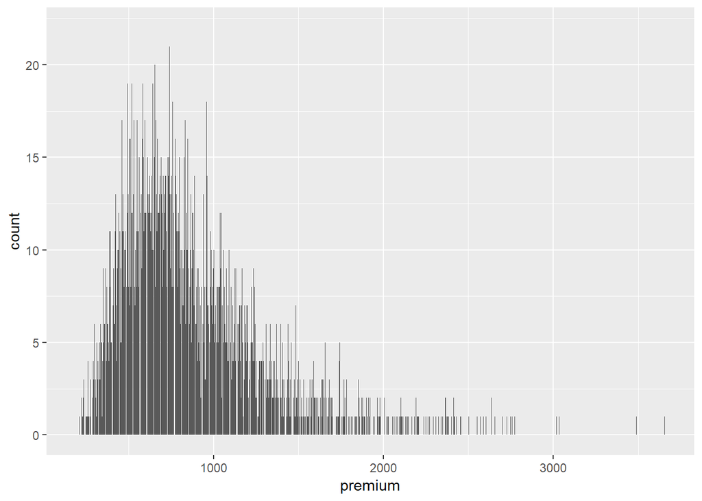

```r
uniform_dist_iid %>%
  ggplot +
  geom_bar(aes(x = premium))
```

This is great result. The ratings factors themselves are generated using loss cost models. Even though we randomly generated a feature set there is a clear transfomation that occurs just by using rating factors selected from generlized linear model (usually).

### Not Uniformly Distributed, Independent Mix of Business

### Not Uniformly Distributed, Dependent Mix of Business

### Extreme Sample Bias

What if 90% of the data was male rather than female.

## Learning Extension of Exposures - Proof of Concept

### Data Preparation and Required Packages

The `keras` package offers a great way to quickly fit neural nets for research. Refer to the `keras` package for more detail and most everything you need to know about modeling with `keras`. The [Keras site](https://keras.rstudio.com/) is a great place to start. I’m using the GPU setup of tensorflow— it takes longer to setup but it fits the model much faster.

Note we did not scale any of the features or the output. This is not best practice. Because we’re not using many features, the dataset is pretty small (e.g. 10^{4} rows) and we know the range of premiums is limited from 189 to 3656 it won’t take extra computational time.

### Model Setup

We keep the model pretty simple for now. The ReLu activation is used to keep things greater than zero and not limited by a maximum.

```r
model <-
  keras_model_sequential() %>%
  layer_dense(units = 64, activation = 'linear', input_shape = c(x_train %>% ncol)) %>%
  layer_dense(units = 32, activation = 'linear') %>%
  layer_dense(units = 1 , activation = 'relu')

model %>% compile(
  loss = 'mean_absolute_error',
  optimizer = optimizer_rmsprop()
)
```

### First Time leennR

Fitting the model is quite simple. The model is trained for 300 epochs.

```r
model %>% summary()
```

```
## ___________________________________________________________________________
## Layer (type)                     Output Shape                  Param #
## ===========================================================================
## dense (Dense)                    (None, 64)                    704
## ___________________________________________________________________________
## dense_1 (Dense)                  (None, 32)                    2080
## ___________________________________________________________________________
## dense_2 (Dense)                  (None, 1)                     33
## ===========================================================================
## Total params: 2,817
## Trainable params: 2,817
## Non-trainable params: 0
## ___________________________________________________________________________
```

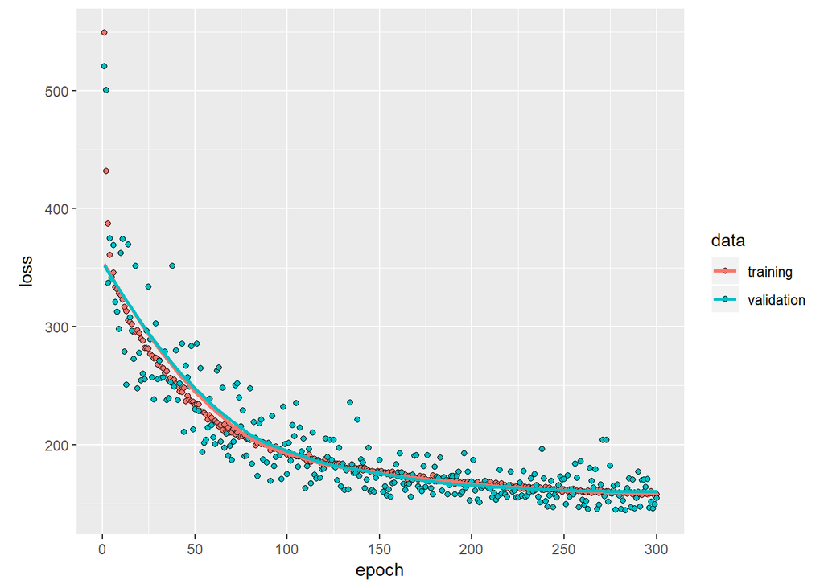

```r
plot(history)
```

```r
mse <- history$metrics$loss %>% tail(., 1) / nrow(x_train)

paste0("Mean absolute error on test set: $", sprintf("%.2f", mse))
```

[output not shown]

```r
model %>% evaluate(x_test, y_test)
```

```
##     loss
## 162.7092
```

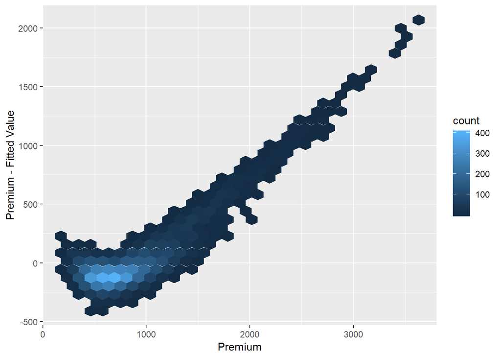

```r
predict <-
  x_train %>%
  cbind.data.frame(
    y_train,
    y_hat =
      model %>%
      predict(x_train)) %>%
  as_tibble

predict_test <-
  x_test %>%
  cbind.data.frame(
    y_train,
    y_hat =
      model %>%
      predict(x_test)) %>%
  as_tibble

# predict %>%
#   ggplot +
#   geom_jitter(aes(x = premium, y = abs(y_hat - premium)/premium)) +
#   xlab("Premium") +
#   ylab("Absolute Error as % of Premium")

predict %>%
  ggplot +
  geom_hex(aes(x = premium, y = premium - y_hat)) +
  xlab("Premium") +
  ylab("Premium - Fitted Value")
```

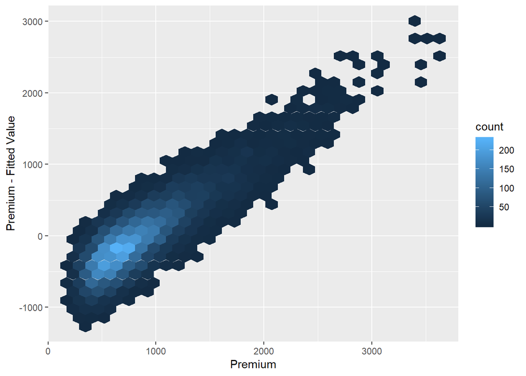

```r
# predict_test %>%
#   ggplot +
#   geom_jitter(aes(x = premium, y = abs(y_hat - premium)/premium)) +
#   xlab("Premium") +
#   ylab("Absolute Error as % of Premium")

predict_test %>%
  ggplot +
  geom_hex(aes(x = premium, y = premium - y_hat)) +
  xlab("Premium") +
  ylab("Premium - Fitted Value")
```

### Randomness and error of fit

Over fitting? We should overfit! Error is missing data or incorrect structure of net (need deeper or mimic rating algorithm).

Loss data is random. Premiums should not be. Use the GLM argument. Use the closed system argument.

## The leennr Proof of Concept

### Simulate Rate Changes - this is needed to

### Simulate Written Premium Transactions

Does it matter if we use earnings or written premiuums

## Research

Further research needs to be done in order to justify this work with the department of insurance. In other words, what guidance can be provided so that departments of insurance can accept this method.

Here we resarch possible pitfalls with this method and the limitations. Also, can we use these models for production purposes.

### Number of Price Points and Needed Layers

### Is it right?

Depends on the data. If the insurance data is wrong it produce correct onleveled premiums for the actuary but it will not point out production problems in rating.

A few rating examples can datermine.

### Method

How am I approaching data creation.

#### Does it matter if we do not correlation among cohorts?

## More

### Revisiting Rating Examples with Deeper Nets

With all the background up to this point we introduce depper networks to represenet non-linear rating example.